# Practical File

Sudeep Kumar Singh

28021

BSc Computer Science Hons.

**Unit:-1**

**1. Introduction to Python**

**Definition:** Python is a high-level, interpreted programming language known for its simplicity and readability. It is widely used for web development, data science, automation, and machine learning.

```python
#Python Implementation:-
# Printing Hello, World!
print("Hello, World!")

print("Python is a powerful language capable of Artificial Intelligence and Machine Learning.")
print("It is widely used for data science, automation, and web development.")
print("=" * 80)
```

```
Hello, World!
Python is a powerful language capable of Artificial Intelligence and Machine Learning.
It is widely used for data science, automation, and web development.
================================================================================
```

**2. Python vs. Excel**

**Definition:** Python and Excel are both used for data analysis, but Python provides automation, scalability, and better handling of large datasets compared to Excel's manual operations.

- **Automation:** Python allows users to automate repetitive tasks and complex workflows, reducing manual effort and errors common in Excel.
- **Scalability:** Python can efficiently process and analyze large datasets that may slow down or crash Excel.
- **Advanced Analytics:** Python supports advanced statistical, machine learning, and visualization libraries, offering more powerful analysis than Excel's built-in tools.

```python
#Python Implementation: Using Pandas to read an Excel file.
# Reading the Excel file named 'data.xlsx' in the current directory
import pandas as pd
data = pd.read_excel("indian_data.xlsx")
print(data.head())
print("=" * 80)
```

```
      Name   Age  Salary       City
0  Karthik  30.0   50000  Bengaluru
1   Ananya  24.0   60000     Mumbai
2    Meena   NaN   45000      Delhi
3    Meena  24.0   45000      Delhi
4  Karthik  30.0   50000  Bengaluru
================================================================================
```

**3. Anaconda and Jupyter Notebook: Interface Overview**

**Definition:**

Anaconda is a popular Python distribution designed for scientific computing and data science. Jupyter Notebook is an interactive environment that allows you to write code, visualize results, and add markdown notes—all in one place. It supports live code execution, making it ideal for data analysis, visualization, and documentation.

```python
#Python Implementation: Running a simple Python cell in Jupyter Notebook.
# Simple arithmetic operation
print(5 + 9)
print(3 * 85)
print(67 - 70)
print(104 / 11)
print("=" * 80)
```

```
14
255
-3
9.454545454545455
================================================================================
```

**4. Data Types in Python**

**Definition:** Python supports various data types, including integers, floats, strings, lists, tuples, sets, and dictionaries.

```python
#Python Implementation:-
# Different data types in Python (Indian example)
integer_val = 75  # e.g., age of a person
float_val = 98.6  # e.g., average temperature in India
string_val = "Delhi"  # e.g., name of a city
list_val = ["Mumbai", "Chennai", "Kolkata", "Delhi"]  # list of Indian metro cities
tuple_val = ("Karthik", 30, "Bengaluru")  # tuple with name, age, city
dict_val = {"name": "Ananya", "age": 24, "city": "Mumbai"}  # dictionary with Indian context

print(type(integer_val), type(float_val), type(string_val), type(list_val), type(tuple_val), type(dict_val))

print("=" * 80)
```

```
<class 'int'> <class 'float'> <class 'str'> <class 'list'> <class 'tuple'> <class 'dict'>
================================================================================
```

**5. Python Basic Syntax**

*Assignment Statements and Variables*

```python
# Assigning values to variables
x = 10
y = 90
z = x + y
print("Sum:", z)

print("=" * 80)
```

```
Sum: 100
================================================================================
```

```python
# Assiging alphabetic values to variables
a = "Sudeep Kumar"
b = "Singh"
print("Concatenate two strings", a + " " + b)
print("Replicating a string", a*2)
print("=" * 80)
```

```
Concatenate two strings Sudeep Kumar Singh
Replicating a string Sudeep KumarSudeep Kumar
================================================================================
```

*Indentation*

```python
# Proper indentation in Python
print("Indentation is required for sub statement.")
print("It is four space or a tab.")
if True:
    print("This is indented correctly!")

print("=" * 80)
```

```
Indentation is required for sub statement.
It is four space or a tab.
This is indented correctly!
================================================================================
```

*Conditionals*

```python
# If-Else Condition
num = 10
if num > 0:
    print("Positive number")
else:
    print("Negative number")

print("=" * 80)
```

```
Positive number
================================================================================
```

```python
# If-Else Condition
age = int(input("Enter your age: "))
if age >= 18:
    print("You may drive any vehicle")
else:
    print("You cannot drive any vehicle")

print("=" * 80)
```

```
Enter your age:  45
```

```
You may drive any vehicle
================================================================================
```

```python
# If-Else Ladder
marks = int(input("Enter your marks"))
if marks >= 90:
    print("You got grade \"O\"")
elif marks >= 80 and marks< 90:
    print("You got grade \"A+\"")
elif marks >= 70 and marks< 80:
    print("You got grade \"A\"")
elif marks >= 60 and marks< 70:
    print("You got grade \"B+\"")
elif marks >= 50 and marks< 60:
    print("You got grade \"B\"")
elif marks >= 40 and marks< 50:
    print("You got grade \"C+\"")
elif marks >= 33 and marks< 40:
    print("You got grade \"C\"")
else:
     print("You are Fail. Better luck next time!")

print("=" * 80)
```

```
You got grade "O"
================================================================================
```

*Loops* - For & While

```python
# For loop
for i in range(5):
    print(i)

# While loop
count = 0
while count < 5:
    print(count)
    count += 1

print("=" * 80)
```

```
0
1
2
3
4
0
1
2
3
4
================================================================================
```

```python
#For loop
num = int(input("Enter the number which table you want to print"))
for i in range(1, 11):
    print(f"{num} x {i} = {num * i}")

print("=" * 80)
```

```
99 x 1 = 99
99 x 2 = 198
99 x 3 = 297
99 x 4 = 396
99 x 5 = 495
99 x 6 = 594
99 x 7 = 693
99 x 8 = 792
99 x 9 = 891
99 x 10 = 990
================================================================================
```

```python
num = int(input("Enter the number which table you want to print"))
i = 1

while i <= 10:
    print(f"{num} x {i} = {num * i}")
    i += 1
```

```
13 x 1 = 13
13 x 2 = 26
13 x 3 = 39
13 x 4 = 52
13 x 5 = 65
13 x 6 = 78
13 x 7 = 91
13 x 8 = 104
13 x 9 = 117
13 x 10 = 130
```

*User-Defined Functions*

```python
#Basic Function (No Parameters, No Return Value)
def greet():
    print(f"Hello, {a}! Welcome to Python functions.")

# Calling the function
greet()
```

```
Hello, Sudeep Kumar! Welcome to Python functions.
```

```python
#Function with Parameters and Return Value
def add(a, b):
    return a + b

# Calling the function
result = add(10, 5)
print("Sum:", result)
```

```
Sum: 15
```

```python
#Function with Default Arguments
def greet_user(name="Programmer"):
    print(f"Hello, {name}!")

greet_user("Sudeepwebdev")    # With argument
greet_user()           # Uses default value
```

```
Hello, Sudeepwebdev!
Hello, Programmer!
```

```python
#Function with List Argument (Process Multiple Items)
def print_odd_numbers(numbers):
    print("Odd numbers:")
    for num in numbers:
        if num % 2 != 0:
            print(num, end=" ")

# Calling the function
nums = [1, 2, 3, 4, 5, 6]
print_odd_numbers(nums)
```

```
Odd numbers:
1 3 5
```

```python
#Recursive Function (Factorial Example)
def factorial(n):
    if n == 0 or n == 1:
        return 1
    return n * factorial(n - 1)

# Calling the recursive function
print("Factorial of 5 is:", factorial(5))
```

```
Factorial of 5 is: 120
```

```python
# Function to calculate square of a number
def square(num):
    return num ** 2

print(square(4))

print("=" * 80)
```

```
16
================================================================================
```

**6. Working with Libraries**

*Pandas*

```python
#Creating DataFrame from a List of Dictionaries
import pandas as pd

# Creating a DataFrame from list of dictionaries with Indian names and 'EName'
data = [
    {"EName": "Karthik", "Age": 30, "City": "Bengaluru"},
    {"EName": "Ananya", "Age": 24, "City": "Mumbai"}
]
df1 = pd.DataFrame(data)
print(df1)
print("=" * 80)
```

```
     EName  Age       City
0  Karthik   30  Bengaluru
1   Ananya   24     Mumbai
================================================================================
```

```python
#Creating DataFrame from a Dictionary of Series
import pandas as pd

# Creating Series for each column
names = pd.Series(["SUmit", "Farhan"])
ages = pd.Series([40, 22])
cities = pd.Series(["Chicago", "Delhi"])

# Creating DataFrame
data = {
    "Name": names,
    "Age": ages,
    "City": cities
}
df2 = pd.DataFrame(data)
print(df2)
print("=" * 80)
```

```
     Name  Age     City
0   SUmit   40  Chicago
1  Farhan   22    Delhi
================================================================================
```

```python
#Creating DataFrame from List of Lists with Custom Column Names
import pandas as pd

# List of lists
data = [
    ["George", 45, "Seattle"],
    ["Hannah", 32, "Boston"]
]

# Specifying column names
columns = ["Name", "Age", "City"]

# Creating DataFrame
df3 = pd.DataFrame(data, columns=columns)
print(df3)
print("=" * 80)
```

```
     Name  Age     City
0  George   45  Seattle
1  Hannah   32   Boston
================================================================================
```

```python
import pandas as pd

# Creating a DataFrame
data = {"Name": ["Alice", "Bob"], "Age": [25, 30]}
df = pd.DataFrame(data)
print(df)
print("=" * 80)
```

```
    Name  Age
0  Alice   25
1    Bob   30
================================================================================
```

*NumPy*

```python
#Creating an Array with np.arange()
import numpy as np

# Array with range of numbers
arr2 = np.arange(1, 6)  # [1, 2, 3, 4, 5]
print("Array from arange multiplied by 3:\n", arr2 * 3)
print("=" * 80)
```

```
Array from arange multiplied by 3:
 [ 3  6  9 12 15]
================================================================================
```

```python
#Creating an Array with np.zeros() and Broadcasting
import numpy as np

# Array filled with zeros
arr3 = np.zeros((2, 3))  # 2x3 matrix of zeros
print("Zeros array plus 5:\n", arr3 + 5)
print("=" * 80)
```

```
Zeros array plus 5:
 [[5. 5. 5.]
 [5. 5. 5.]]
================================================================================
```

```python
#Creating a 2D NumPy Array (Matrix)
import numpy as np

# 2D Array (Matrix)
arr1 = np.array([[1, 2], [3, 4]])
print("2D Array multiplied by 2:\n", arr1 * 2)
print("=" * 80)
```

```
2D Array multiplied by 2:
 [[2 4]
 [6 8]]
================================================================================
```

```python
import numpy as np

# Creating a NumPy array
arr = np.array([1, 2, 3, 4])
print(arr * 2)

print("=" * 80)
```

```
[2 4 6 8]
================================================================================
```

*Matplotlib*

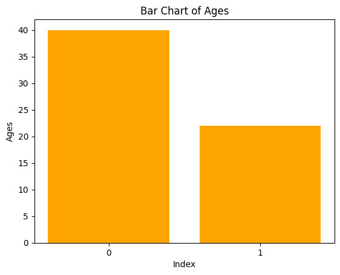

```python
import matplotlib.pyplot as plt

# Use the 'ages' Series for the bar chart
plt.bar(ages.index.astype(str), ages.values, color='orange')
plt.xlabel("Index")
plt.ylabel("Ages")
plt.title("Bar Chart of Ages")
plt.show()

print("=" * 80)
```

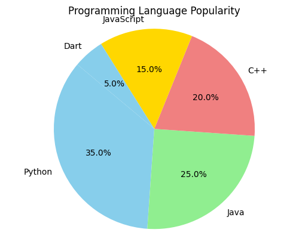

```python
#Pie Chart
import matplotlib.pyplot as plt

# Data for pie chart
labels = ['Python', 'Java', 'C++', 'JavaScript', 'Dart']
sizes = [35, 25, 20, 15 ,5]
colors = ['skyblue', 'lightgreen', 'lightcoral', 'gold']

plt.pie(sizes, labels=labels, colors=colors, autopct='%1.1f%%', startangle=140)
plt.title("Programming Language Popularity")
plt.axis('equal')
plt.show()

print("=" * 80)
```

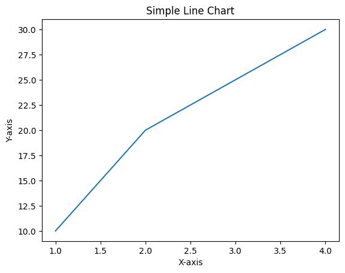

```python
import matplotlib.pyplot as plt

# Plotting a simple line chart
x = [1, 2, 3, 4]
y = [10, 20, 25, 30]
plt.plot(x, y)
plt.xlabel("X-axis")
plt.ylabel("Y-axis")
plt.title("Simple Line Chart")
plt.show()

print("=" * 80)
```

*Seaborn*

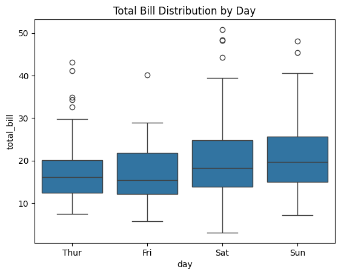

```python
 #Box Plot
import seaborn as sns
import matplotlib.pyplot as plt

# Load sample dataset
data = sns.load_dataset("tips")

# Creating a box plot
sns.boxplot(x="day", y="total_bill", data=data)
plt.title("Total Bill Distribution by Day")
plt.show()

print("=" * 80)
```

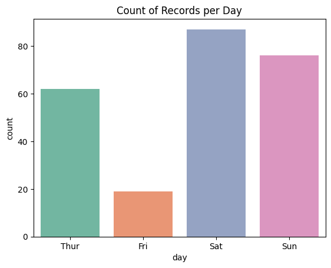

```python
#Count Plot
import seaborn as sns
import matplotlib.pyplot as plt

# Load sample dataset
data = sns.load_dataset("tips")

# Creating a count plot
sns.countplot(x="day", data=data, palette="Set2")
plt.title("Count of Records per Day")
plt.show()

print("=" * 80)
```

[figure not shown]

```python
#Histogram with KDE (Distribution Plot)
import seaborn as sns
import matplotlib.pyplot as plt

# Load sample dataset
data = sns.load_dataset("tips")

# Creating a histogram with KDE
sns.histplot(data["total_bill"], kde=True, color="purple")
plt.title("Distribution of  Bills")
plt.xlabel("Total Bill")
plt.ylabel("Frequency")
plt.show()

print("=" * 80)
```

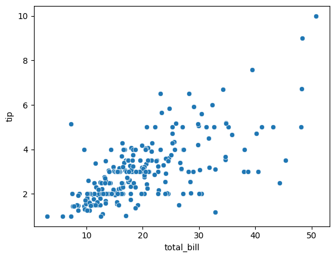

```python
import seaborn as sns
import matplotlib.pyplot as plt

# Sample data
data = sns.load_dataset("tips")

# Creating a scatter plot
sns.scatterplot(x="total_bill", y="tip", data=data)
plt.show()

print("=" * 80)
```

**Comparison between Matplotlib and Seaborn**

1. Matplotlib offers more control and is lower-level (you design everything).
2. Seaborn is built on top of Matplotlib and provides prettier, more statistically-informed plots with less code.

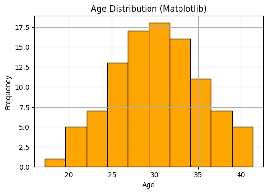

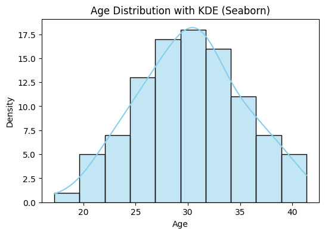

```python
#Histogram with KDE (Distribution Plot)
import matplotlib.pyplot as plt
import seaborn as sns
import pandas as pd
import numpy as np

# Sample data: Age distribution
np.random.seed(0)
ages = np.random.normal(loc=30, scale=5, size=100)

# ------------------ Matplotlib ------------------
plt.figure(figsize=(6, 4))
plt.hist(ages, bins=10, color='orange', edgecolor='black')
plt.title("Age Distribution (Matplotlib)")
plt.xlabel("Age")
plt.ylabel("Frequency")
plt.grid(True)
plt.show()

# ------------------ Seaborn ------------------
plt.figure(figsize=(6, 4))
sns.histplot(ages, bins=10, kde=True, color='skyblue')
plt.title("Age Distribution with KDE (Seaborn)")
plt.xlabel("Age")
plt.ylabel("Density")
plt.show()

print("=" * 80)
```

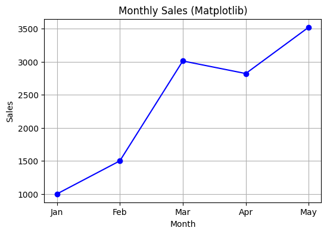

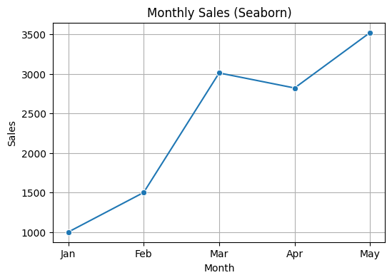

```python
#Line Plot – Sales Over Months
import matplotlib.pyplot as plt
import seaborn as sns
import pandas as pd

# Sample dataset
data = {
    'Month': ['Jan', 'Feb', 'Mar', 'Apr', 'May'],
    'Sales': [1000, 1500, 3010, 2820, 3520]
}
df = pd.DataFrame(data)

# ------------------ Matplotlib ------------------
plt.figure(figsize=(6, 4))
plt.plot(df['Month'], df['Sales'], marker='o', color='blue')
plt.title("Monthly Sales (Matplotlib)")
plt.xlabel("Month")
plt.ylabel("Sales")
plt.grid(True)
plt.show()

# ------------------ Seaborn ------------------
plt.figure(figsize=(6, 4))
sns.lineplot(x='Month', y='Sales', data=df, marker='o')
plt.title("Monthly Sales (Seaborn)")
plt.xlabel("Month")
plt.ylabel("Sales")
plt.grid(True)
plt.show()

print("=" * 80)
```

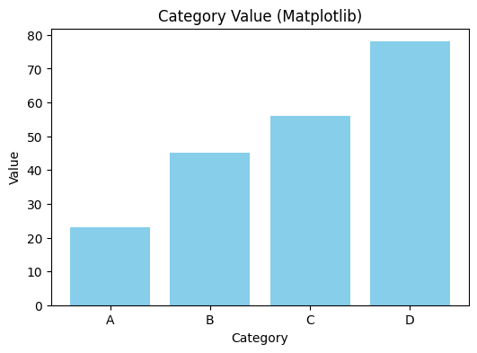

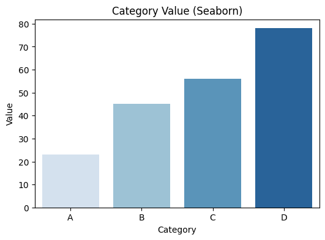

```python
#Bar Plot – Category vs Value
# Sample dataset
category_data = {
    'Category': ['A', 'B', 'C', 'D'],
    'Value': [23, 45, 56, 78]
}
df2 = pd.DataFrame(category_data)

# ------------------ Matplotlib ------------------
plt.figure(figsize=(6, 4))
plt.bar(df2['Category'], df2['Value'], color='skyblue')
plt.title("Category Value (Matplotlib)")
plt.xlabel("Category")
plt.ylabel("Value")
plt.show()

# ------------------ Seaborn ------------------
plt.figure(figsize=(6, 4))
sns.barplot(x='Category', y='Value', data=df2, palette='Blues')
plt.title("Category Value (Seaborn)")
plt.xlabel("Category")
plt.ylabel("Value")
plt.show()

print("=" * 80)
```

**7. Python SQL Database Access**

```python
import sqlite3
# Connecting to a database
conn = sqlite3.connect("example.db")
cursor = conn.cursor()
```

*Creating a Table*

```python
cursor.execute('''CREATE TABLE IF NOT EXISTS students (
                    id INTEGER PRIMARY KEY,
                    name TEXT,
                    age INTEGER)''')
conn.commit()
```

*Inserting Data*

```python
cursor.execute("INSERT INTO students (name, age) VALUES (?, ?)", ("Sudeep", 22))
cursor.execute("INSERT INTO students (name, age) VALUES (?, ?)", ("Ravi", 23))
cursor.execute("INSERT INTO students (name, age) VALUES (?, ?)", ("Amit", 21))
cursor.execute("INSERT INTO students (name, age) VALUES (?, ?)", ("Priya", 22))
cursor.execute("INSERT INTO students (name, age) VALUES (?, ?)", ("Neha", 20))
cursor.execute("INSERT INTO students (name, age) VALUES (?, ?)", ("Rahul", 24))
cursor.execute("INSERT INTO students (name, age) VALUES (?, ?)", ("Anjali", 23))
cursor.execute("INSERT INTO students (name, age) VALUES (?, ?)", ("Vikram", 22))
cursor.execute("INSERT INTO students (name, age) VALUES (?, ?)", ("Deepa", 21))
cursor.execute("INSERT INTO students (name, age) VALUES (?, ?)", ("Twinkle", 25))
cursor.execute("INSERT INTO students (name, age) VALUES (?, ?)", ("Meena", 20))
conn.commit()
```

*Fetching Data*

```python
cursor.execute("SELECT * FROM students")
rows = cursor.fetchall()
for row in rows:
    print(row)
```

```
(1, 'Sudeep', 22)
(2, 'Ravi', 23)
(3, 'Amit', 21)
(4, 'Priya', 22)
(5, 'Neha', 20)
(6, 'Rahul', 24)
(7, 'Anjali', 23)
(8, 'Vikram', 22)
(9, 'Deepa', 21)
(10, 'Twinkle', 25)
(11, 'Meena', 20)
```

*Deleting Data*

```python
cursor.execute("DELETE FROM students WHERE name = ?", ("Ramesh",))
cursor.execute("DELETE FROM students WHERE name = ?", ("Neha",))
conn.commit()
```

```python
cursor.execute("SELECT * FROM students")
rows = cursor.fetchall()
for row in rows:
    print(row)
```

```
(1, 'Sudeep', 22)
(2, 'Ravi', 23)
(3, 'Amit', 21)
(4, 'Priya', 22)
(6, 'Rahul', 24)
(7, 'Anjali', 23)
(8, 'Vikram', 22)
(9, 'Deepa', 21)
(10, 'Twinkle', 25)
(11, 'Meena', 20)
```

*Closing Connection*

```python
conn.close()
```

**Unit:2**

**1. Pandas**

**Definition:** Pandas is an open-source Python library used for data manipulation and analysis. It provides data structures like Series (1D) and DataFrame (2D) that are powerful and flexible for handling structured data.